# The Nature of Time Series Analysis: Phenological Study of Gulf Coast Turtle Nesting Activity

Author

Rachel Hudson (Advisors: Dr. Pu, Dr. Seals, Dr. Schmutz)

### ABSTRACT

Are the nesting habits of Loggerhead Turtles predictable? Can we look back on data and external environmental factors, such as sea surface temperature, to forecast what the future has in store for Loggerhead Turtle populations based on the past observed number of nest sites found along the Gulf Coast? Nesting data was collected from Perdido Key, Fort Pickens, Pensacola Beach, and Santa Rosa Beach and we were able to collect Sea Surface Temperature (SST) data from a buoy within an approved proximity to the beaches. Our subject matter consisted of biological data that is highly seasonal. The Time Series Analysis (TSA) process comprises of analyzing seasonal components - both long and short term - within a data series. Therefore, TSA was most suited to decompose the series and synthesize its results. After looking at relationships in the raw data, testing grouping viability (daily vs. monthly), selecting an apprpriate model to represent the data, and fitting the resultant model to help forecasting efforts, we were able to correctly predict the last two years of monthly nesting counts with a 95% confidence interval even with a dip in the nest counts for 2019. Our final model predicted that nest counts could vary by 4-9 nests each month; however, this finding enables conservationists to allocate their resources more optimally to secure the future population health of Loggerhead turtles.

### INTRODUCTION

This study was a collaborative effort at the University of West Florida; the data was supplied by Dr. Schmutz (Department of Environmental Science) and provided to Dr. Seals (Department of Mathematics and Statistics) to statistically study the nesting habits of Loggerhead Turtles along the Gulf Coast of Florida.

There is much background knowledge to encapsulate the phenological study of Loggerhead turtle’s nesting habits. The “remigration interval (the interval between two successive nesting seasons) and inter-nesting interval (the interval between two successive nesting attempts during the same season) describe the multiple reproductive patterns of the species” (Mazaris 2004; Sato 1998). The remigration interval is usually 2-4 years (Miller 1997). During this period, the turtles inhabit their nutrient-rich foraging and feeding grounds hundreds of miles away (Insights 2025) from their nesting sites. They remain until they replenish their fat reserves for the long journey to and from their nesting sites, as well as the energy-depleting act of producing “a minimum of between two and five clutches per reproductive season” (Miller 1997). Because of the inconsistent frequency of nesting, we can assume that there will be a high degree of variance in nesting counts. As ectothermic creatures, turtles respond to thermal cues such as sea surface temperature (SST) and our data did not originally include this; however, we were able to extract usable temperature data from a proximally-located buoy (Station 42039, 115NM SSE of Pensacola) in the Gulf that spanned the entire observation time of the data series. Closer buoys were available but their data did not span our series; however, we statistically verified Station 42039 by computing an ANOVA comparison to make sure the temperature was within an approved range. The Gulf Coast region is regarded as a very small area of nesting, therefore, several beaches have to be observed at the same time to obtain the amounts of data needed to generate statistically significant results. This allows for a more intimate monitoring of Loggerhead encounters where we all can appreciate the opportunity for female turtles and “their nests, and the resulting hatchlings…” being “…accessible on the beach during the nesting season and provide a baseline for population trends.” (Jacob Andrew Lasala 2023) Unfortunately, Loggerhead turtles have been on the United States Federal Endangered Species Act list as a threatened species since 1978 (FWC 2011), thus the need for conservation efforts along regularly visited beaches, primarily, in Florida as it is host to the nesting habitat of about 90% of the world’s population (FWC 2025).

As an added caveat, we also considered any major events that occurred within our time series span. In 2004, Hurricane Ivan (Category 3) decimated the coastal region in our study. Pensacola Beach, Fort Pickens and Perdido Key were hit directly and in due course their beaches and dunes were ‘rebuilt’, as well as the housing that was washed away with the storm. In 2010, an explosion on the Deepwater Horizon drilling platform leaked approximately 134 million gallons of oil into our immediate Gulf region (NOAA 2025) as well as the Alabama, Mississipi and Louisiana coast; oil was also found along the Texas coastline. Both incidents brought increased anthropogenic activity to the beaches, which likely disrupted the turtles’ nesting window, especially the oil spill where many marine animals and birds had to be ‘degreased’ and rehabilitated. Both of these events could not have been foreseen and they had long-term consequences on the study area.

Time Series Analysis (TSA) was suggested to be the best approach when looking at the seasonal aspect of nesting activity. The methodology of TSA is broken down into steps that can be iterative in nature depending on the results from each step. These steps include exploring the data and possible relationships; examining the stationarity of data; determining which decomposition method will be used (additive or multiplicative); selecting a model to “capture underlying data patterns based on characteristics such as seasonality, trend, and stationarity” (MathWorks 2026); the training and validation of the model; assessing the resulting metrics, forecast outcomes and consequential residuals. Since this is a study on biological data, it is will likely result in a strong seasonal model; therefore, non-linear models will suit the data more consistently, for example, an ARIMA model with a suitable “fit” enhancement.

Our objective is to assess whether the TSA can mitigate stochastic events - the “shocks” or external innovations - within the series time period, 1998-2020, and still be capable of predicting future nesting counts within a statistical margin of error.

Our summary of approach includes all of the classical stages of Time Series Analysis plus a few preliminary steps as well as the integrating the Box -Jenkins method. First of all, we have to make sure we have a viable data set. The data set must be built upon a regular interval timeline, e.g., hours, mins, years etc., then we must remove rows that contain erroneous errors. In our case, we had to create a new data set of Sea Surface Temperature and then merge it with the Nesting Count data using the date as the key variable. We were able to explore the data in its current form using the entire time span by constructing tables and plots to observe whether the data has some inherent relationships. We need to identify our main variable and any exogenous variables within our dataset. The next step is actually the first stage of the Box-Jenkins method. There are 3 stages comprising of Identification, Estimation, and Diagnostic Checks. Within the Identification stage, we determine the Stationarity of the data by testing for its constant mean, variance and autocorrelation. The Augmented Dickey-Fuller test, or Unit Root Test, or the KPSS (Kwiatkowski-Phillips-Schmidt-Shin) Test were used to find $p$-values that numerically convey if the data is stationary. We can also observe the ACF (Auto-Correlation Function) plots and use our interpretation as confirmation of the KPSS $p$-value. We can also determine if there is a seasonality lag associated with data by observing the PACF (Partial Autocorrelation Function) plot. The Estimation stage of the Box-Jenkins method comprises of decomposing the data into Trend, Season, and Residuals/Remainder using an STL (Seasonal and Trend decomposition using Loess) plot, from the feasts (Feature Extraction and Statistics for Time Series), O’Hara-Wild, Hyndman, and Wang (2025), package in R, to determine whether the data decomposition structure is Multiplicative or Additive. A Multiplicative Decomposition will show that the seasonal variations are proportional to the trend, however, the Additive model’s magnitude of the seasonal fluctuations do not depend upon the level of the Trend and will stay about the same. Observing the Trend in STL plot will show if the Trend is linear; if it is not, then one must apply Differencing, (d or D) = 1. If there is a sharp cut-off in the PACF rather than a “tailing off” of the plot spikes, then we may need to apply an AutoRegressive component, p or P. A q or Q component is deemed necessary based upon the remainder in the STL plot as to how well the “shocks” are absorbed during the decomposition of the Trend and Season. One can also find the trend and seasonal strength using the feature function from the feasts package, O’Hara-Wild, Hyndman, and Wang (2025), in R; $F_T$ > 0.6 constitutes as a high trend and $F_S$ > 0.7 is high in Seasonality. Next in the Estimation Stage of the Box-Jenkins method, we generate a basic automated Model of the main variable using the ARIMA and model functions from the fable, O’Hara-Wild (2020), package in R; this will provide us with estimated p, d, q, P, D, Q components and define the model, e.g., ARMA, ARIMA, SARIMA, etc. The report function will estimate the coefficients for the Backshift equation with the degree of certainty shown by the z-statistic. In the final stage of the Box-Jenkins method, Diagnostic Checks, We use the gg_tsresiduals function from the feasts, O’Hara-Wild, Hyndman, and Wang (2025), package in R to generate several plots (Innovation Residuals, ACF, and Residuals) for us to interpret the model’s fit. Moving along to the next TSA step, we are now at the point of Training and Validating the model. We will train most of the data, about 80-90%, and use the most recent data as a test set, 10-20%, to confirm if we are able to forecast accurately. We need to select an appropriate model depending on the Trend; if the Trend was not horizontal, we need to explore non-linear models and identify which has the best fit. We will gauge our model’s best fit by selecting the model with the lowest AIC (Akaike Information Criterion) value to yield the most parsimonious representation of the data. Lastly, forecasting the model will present whether it successfully lies within the 95% Confidence Interval (or 5% significance) using the forecast function from the fable, O’Hara-Wild (2020), package in R. The Ljung-Box Residual Test will generate a quality-of-fit p-value which describes how well the Residuals emulate White Noise. Also, the Residual’s Root Mean Squared Error and Mean Average Error will be calculated to show how far our forecasts are from the observed data.

### METHODS

#### DATA ACQUISITION AND SOURCES

Data was collected from 1998 to 2020 from 4 beaches along the Gulf Coast. Prime nesting season was defined from May through the end of September. Daily observation walks were undertaken to monitor new nesting activity and when a nest was discovered, it immediately populated a date with its unique longitude and latitude of the nesting spot within the dataset; other variables included were the beach that the nest was spotted and the species of turtle that made the nest. There could be several nests found in one day. Water temperature was added from a buoy that had a complete set of data and within the immediate area of the Gulf beaches. The temperature data was added to be used as an external variable to strengthen the forecast of future nesting seasons.

The original dataset contains initials of the locations and species, see below for their full meanings:

- “PB” - “Pensacola Beach”
- “SR” - “Santa Rosa Beach”
- “PK” - “Perdido Key”
- “FP” - “Fort Pickens”
- “CC” - “Caretta caretta”, Loggerhead Turtle
- “CM” - “Chelonia mydas”, Green Turtle
- “DC” - “Dermochelys coriacea”, Leatherback Turtle
- “LK” - “Lepidochelys kempii”, Kemp’s Ridley Turtle

  Although 4 turtle species were identified in the study, our primary focus was on the Loggerhead Turtle, Carrera carrera. Table 1 shows the final dataset columns.

Initial Data Including Water Temperature

Partial Table

| Date | Location | Water Temp (degC) | Latitude (DDeg) | Longitude (DDeg) |
| --- | --- | --- | --- | --- |
| 1998-06-29 | PK | 29.9 | 30.29946 | -87.41041 |
| 1998-06-24 | PK | 30.5 | 30.30090 | -87.40399 |
| 1998-07-07 | PK | 30.8 | 30.30253 | -87.39704 |
| 1998-07-17 | PK | 29.9 | 30.30348 | -87.39326 |
| 1998-06-17 | PK | 29.0 | 30.30486 | -87.38802 |

Individual yearly plots were generated to show the yearly nesting patterns compared to the 22-year average (see Figure 1).

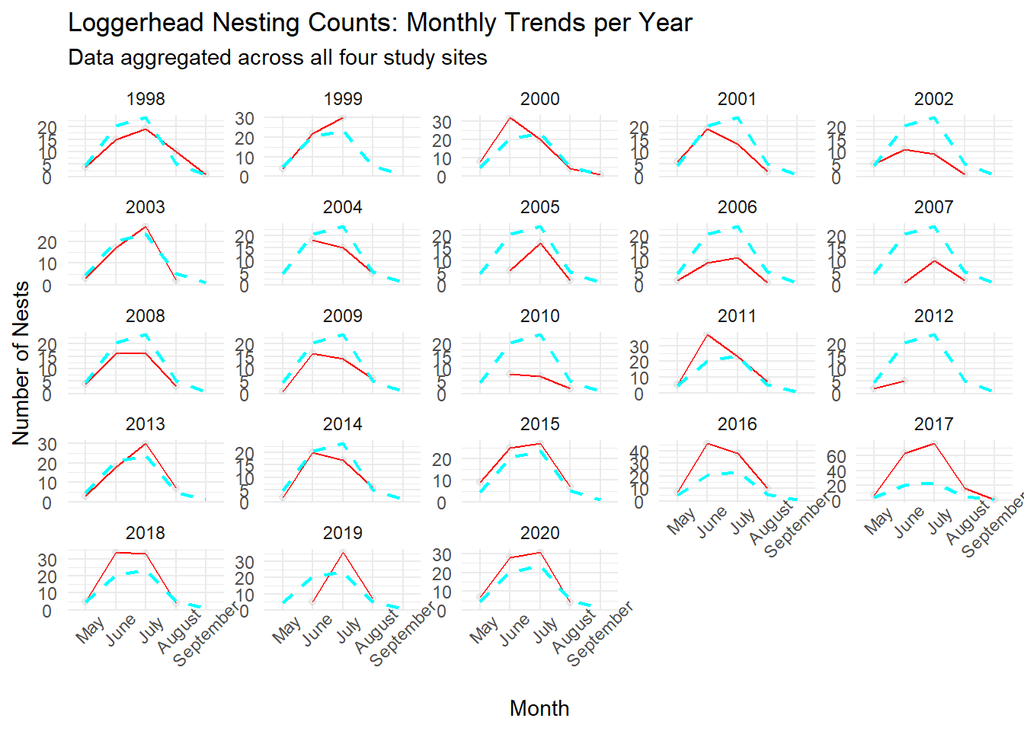

**ADDITIONAL DATA**

Our team decided that we needed temperature data to support the nesting data because turtles react to thermal cues (ectothemic). We found that there are many buoys in the region of study along the Gulf Coast (NOAA, n.d.) and picked two buoys (42012 and 42028) closest to the coastline. Unfortunately, these data sets were incomplete for our needs; the temperature data did not go back 22 years for either buoy. We were able to look further out into the Gulf and found Station PCLF1 and 42039. Station 42028 was dropped from consideration since there was too little data (only 2026 data). We statistically compared PCLF1, 42012, and 42039 with each other to make sure we could use Station 42039 in our analysis.

Table 2: Table of Station Information

Gulf Buoy Station Information

from National Data Buoy Center, NOAA

| Station Number | Location Description | ANOVA Variable | Latitude | Longitude | Date Range |
| --- | --- | --- | --- | --- | --- |
| 42039 | LLNR 115 Pensacola | South_Temp | 28.787 N | 86.007 W | 1998-2020 |
| 42012 | LLNR 138 Orange Beach | OB_temp | 30.060 N | 87.548 W | 2009-2020 |
| PCLF1 | 8729840 - Pensacola, FL | NAS_Temp | 30.404 N | 87.211 W | 2005-2020 |

**ANOVA COMPARISON**

The temperature data from Station 42012, PCLF1, and 42039 were statistically compared using the ANOVA comparison algorithm; the results proved that we would be able to use Station 42039. The *p-value* was less than 0.05 for the comparison between Stations 42012 and 42039 (Orange Beach and Pensacola South) and, also, for the comparison between Stations PCLF1 and 42039 (Pensacola NAS and Pensacola South) which makes the result extremely significant (see Table 3). The average differences between the station temperature of interest (Pensacola South) and the other two 0S0tations was 0.214-0.227 deg Celsius.

Table 3: Tukey HSD Comparison of Mean Water Temperatures

Tukey HSD Comparison of Mean Gulf Water Temperature

95% Confidence Level

| Buoy Contrast | Difference (degC) | Lower Bound | High Bound | Adj. p_value |
| --- | --- | --- | --- | --- |
| OB_Temp-NAS_Temp | -0.0131 | -0.2010 | 0.1748 | 0.9854 |
| South_Temp-NAS_Temp | 0.2141 | 0.0262 | 0.4020 | 0.0207 |
| South_Temp-OB_Temp | 0.2272 | 0.0393 | 0.4151 | 0.0128 |

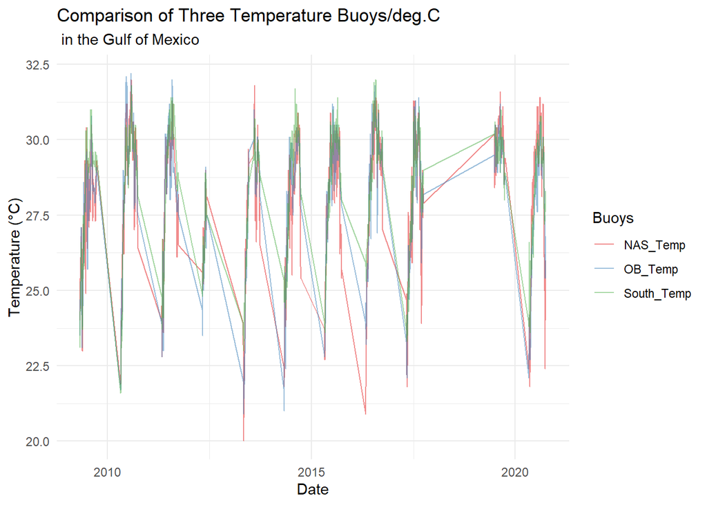

Figure 2: Comparison of Three Temperature Buoys/deg.C

Dr. Schmutz approved of the analysis such that Station 42039 could be used even though it was located 115 Nautical Miles from the Gulf coastline where the turtles nest (see Figure 3 and Figure 2).

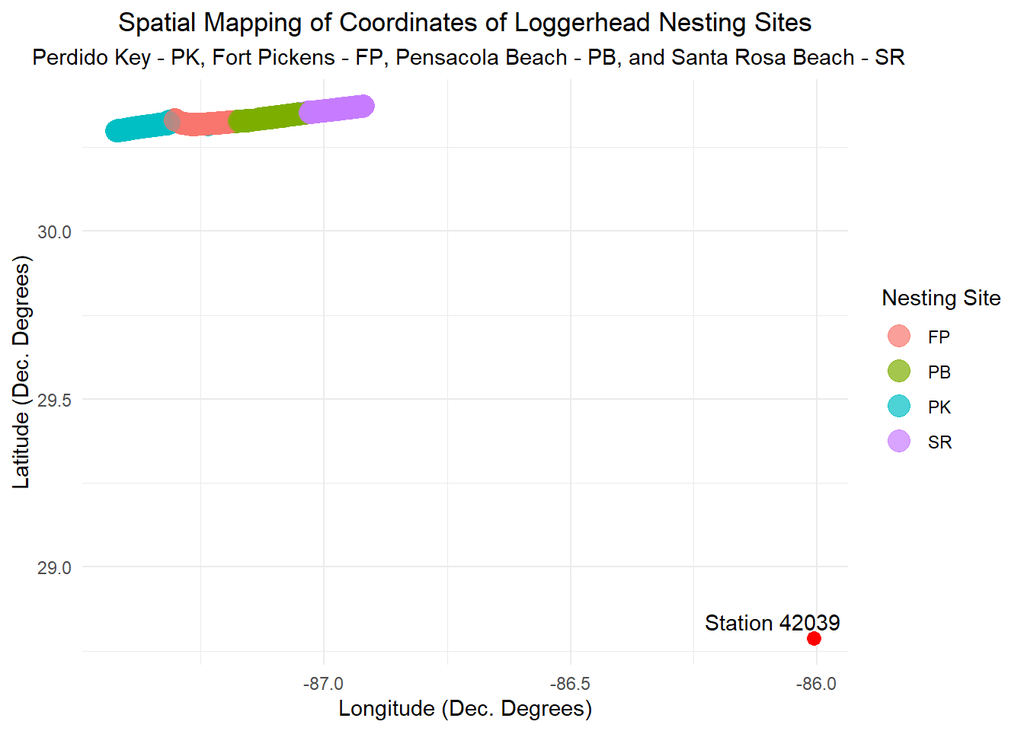

Figure 3: Spatial Mapping Of Loggerhead Nesting Sites including Station 42039 Buoy Location

#### MATHEMATICAL AND STATISTICAL MODELLING

Overall, Time Series Analysis follows a systematic and layered methodology where each layer can strengthen the fit and forecast of the overall model. The main steps of the analysis includes Exploratory Data Analysis and Visualizations, ascertaining the Stationarity of Data, Decomposition Determination, Model Selection, Training and Validation of the model, Forecasting, and Residual Analysis to provide final verification Metrics.

**EXPLORATORY DATA ANALYSIS AND VISUALIZATIONS**

The first series of analysis involves

- making sure the that the points are in time order and occurs at a consistent frequency
- looking for patterns in the data and how the data changes over time
- interpreting whether it contains a Trend or any Seasonality.

At this point, we also need to identify outliers and decide if they are significant for the overall analysis or whether they should be trimmed. It is also important to find any data that could be interpreted as “not applicable” which would also skew the analysis with erroneous results, for example, some data points may have “n/a”, “na”, or a blank/missing value while others may put a number or letter sequence that would not match with the rest of the data. In our data, we found “999” for erroneous readings in the temperature data and blank spaces in the nesting data all of which were filtered out.

**STATIONARITY OF DATA**

There are 3 rules for strict stationarity - a constant mean, constant variance and constant correlation. Constant Mean can manifest as an upward or downward trend denoting that the series is not stationary. Constant Variance shows the volatility of the spread of the data that should stay consistent over the series. Increased deviations (fluctuations) from the average as the series progresses shows non-stationarity. Constant Autocorrelation specifies looking at time t and t-1 and the extent to which they differ; the difference of the internal structure/statistical properties of the data should be constant and not significantly change over time.

An ACF Plot will be generated to show the relationships within the data by observing the prominence and regularity of the plot’s spikes, if the mean is shifting over time by analyzing the correlation between data and lags, and whether Differencing is required to achieve stationarity.

**DECOMPOSITION DETERMINATION**

Classical Decomposition Methods comprise of two main methods: Additive (1) and Multiplicative (2). For additive decomposition, the magnitude of the seasonal fluctuations (or variation about the trend) are not expected to vary with the level of the time series as the data grows, or shrinks, over time. Essentially, we are assuming that there will be a constant absolute magnitude about which there will be seasonal fluctuations. An additive model’s graphical representation will show that there will be parallel peaks and troughs with a consistently even width between them, respectively, even though the overall graph may be showing a positive or negative correlation. The components ($S$, $T$, $R$) are proven to be independent by performing an additive decomposition and checking to see how $R$ (remainder/noise) performs - if $R$ remains fairly consistent, then an additive decomposition is needed; however, if $R$ oscillates and increases in magnitude (and continues to do so) then the multiplicative decomposition has to be used.

$$\begin{equation}
y_t = S_t + T_t + R_t
\end{equation}$$
where S=Seasonal, T=Trend, R=Residuals/Noise at time *t*

The multiplicative decomposition is used when the the magnitude of the seasonal fluctuations are proportional to the level of the time series. Essentially, there is a percentage change between the start and the end of each season and, as aforementioned, the residuals are checked for continually increasing oscillations.

$$\begin{equation}
y_t = S_t \times T_t \times R_t
\end{equation}$$
where y=Observation, S=Seasonal, T=Trend, R=Residuals/Noise at time *t*

“STL is a versatile and robust method for decomposing time series”(Hyndman 2025). STL using Loess is an acronym for Seasonal-Trend decomposition using Locally Estimated Scatterplot Smoothing. Each $S$, $T$, and $R$ component is extracted from the observed data and plotted. When rendering the plot for the STL decomposition on an observed data, it is inherently additive; however, one can take the log of the observed data (and add a constant, if necessary, to aid convergence) and produce a multiplicative decomposition. We then compare the two renderings. One must conduct a comparison of the Remainder, $R$, to decipher which plot more closely resembles White Noise. Another observation in the STL is taking note as to how the Trend handles “shocks” in data. If the Trend is able to smooth over a “shock” in the data, then the “shock” has been successfully transferred to the Remainder; if it can not, then it is called “Leakage’ and the Trend absorbs the anomaly causing the Trend line to become more unstable.

The Trend Strength, $F_T$ (3), is the comparison of Remainder ($R_t$) versus the variance of the Data-without-Trend ($T_t + R_t$) and how much data volatility there is in the long term.

$$\begin{equation}
F_T = max(0,1-[Var(R_t)/Var(m_t + R_t)])
\end{equation}$$
where F=Strength, T=Trend, R=Residuals/Noise at time *t* (Hyndman 2025)

The Seasonal Strength, $F_S$ (4), is the comparison of Remainder ($R_t$) versus the reduction in variance of the Seasonally-Adjusted data ($S_t + R_t$) after the Trend has been removed. Both Seasonal Strength and Trend Strength are measured on a range from 0 (no strength/trend) to 1 (strong strength/trend. Alos, both Strengths can be computed using the features function in the feasts, O’Hara-Wild, Hyndman, and Wang (2025), package in R.

$$\begin{equation}
F_s = max(0,1-[Var(R_t)/Var(s_t + R_t)])
\end{equation}$$
where F=Strength, s=seasonal, R=Residuals/Noise at time *t* (Hyndman 2025)

**MODEL SELECTION**

SARIMAX (Seasonal Autoregressive Integrated Moving Average with an Exogenous Variable) is a comprehensive time series analysis that is a combination of seasonality, autoregression, differencing, moving average, and a forecasting method that is well suited to a biological analysis. It is an extension of the ARIMA framework that incorporates the annual seasonality of biological data and the exogenous variable, in our case, water temperature. Like ARIMA, SARIMAX analysis data has to be proven stationary by testing its mean and variance to ensure that future predictions are based solidly on historical pattern recognition. The S (Seasonal) Component represents the regular intervals at which a relationship can be identified; this is to be expected using biological data, i.e., finding the natural rythmn of the model. The AR (Autoregressive) Component, $p$ or $P$, involves the model using the relationship of the variable with its own previous values (or lagged observations). The I (Integrated) Component, $d$ or $D$, helps to stabilize the mean and remove trends from the time series analysis and makes it stationary by differencing. The MA (Moving Average) Component, $q$ or $Q$, represents the effect of previous error terms on the present value of the time series. The $X$ (eXogenous) Component is an external variable that can help fill in the gaps of past behaviour of the data to soften fluctuations and strengthen future predictions. For this analysis, our exogenous variable is the Gulf of Mexico Surface Water Temperature. The SARIMAX model is mathematically represented using a Backshift ($B$) notation where $By_t=y_{t-1}$ or the current Backshift of the observed data is equal to the observed data one unit of time ago:

$$\begin{equation}
\Phi_P(B^s)\phi_p(B)\nabla^d\nabla_s^Dy_t=\beta x_t+\Theta_Q (B^s)\theta_q(B)\epsilon_t
\end{equation}$$

where $y_t$ is the Dependent Variable, total nesting count; $x_t$ is the Exogenous Variable, surface water temperature; $\beta$ is the Coefficient, quantifies impact of water temperature on nesting activity; $\nabla^d$ and $\nabla_s^D$ are the Differencing Operators; $\phi_p$ and $\Phi_P$ are the AR($p$) and SAR($P$) Components; $\theta_q$ and $\Theta_Q$ are the MA($q$) and SMA($Q$) Components, and $\epsilon_t$ is the White Noise (error term).

The Box-Jenkins time series method will be used and has three steps that intertwines with the time series analysis steps; collectively, they can be run through iteratively. The ‘Identification’ stage determines the order of the Seasonal and non-seasonal AR, I and MA components that are appropriate for the time series and where the exogenous variable is incorporated. Within this step, there is a Stationarity Check for stability using the mean and variance of the model and this includes determining the Seasonal Stationarity. If there are significant fluntuations in the Mean (from analyzing the peaks and troughs), Seasonal Differencing($D$) and, possibly, Standard Differencing ($d$). Next, the Autocorrelation and Partial Autocorrelation Analysis (ACF and PACF) plots are generated to identify model lags or Seasonal Spikes (most probably a multiple of 12). The spikes will be used to identify the Seasonal Autoregressive ($P$) and Seasonal Moving Average ($Q$). The Seasonality Check of the data is to confirm that there is a repeating 12-month pattern, or biological cycle where s=12, thus, validating the “S” component in SARIMAX. The relationship between the Exogenous Variable ($X$) and the time series nedds to be identified appropriately such that it is statistically relavent and aligned (may have to impose a lag) to the overall model and can help explain the model’s behaviour. The ‘Estimation’ stage is where the a model is selected based on the identified seasonal and non-seasonal parameters $(p, d, q)$ x $(P,D,Q)_s$. The AR and MA lags are also selected based on the ACF and PACF found in the previous identification step. The non-seasonal AR ($\phi$) and MA coefficients ($\theta$) will be designated as well as the seasonal AR ($\Phi$) and MA ($\Theta$) coefficients, if they exist. Lastly, for this step, the SARIMAX model’s exogenous variable coefficient ($\beta$) can be estimated. All of these parameters will be applied and the model will generate the fitted values to synthesize its unique historical behavior and predictive nature while amalgamating its historic patterns with the exogenous temperature data. The Akaike Information Criterion (AIC) will be used to select the most parsimonious model to ensure accuracy using as few parameters as possible - too many parameters can diminish the model’s optimization. The ‘Diagnostic Check’ stage involves investigating the residuals (the difference between the predicted SARIMAX values and observed data) to ensure no additional patterns are left in the error/residual terms; the residuals should resemble “white noise” randomness. Next, the Ljung-Box Test is utilized to check to see if the residuals are as desired, i.e., random, followed by a mean and variance check; the desired outcome is that the residuals have a mean about zero and a variance that is constant (homoscedasticity) confirming that the residuals do not grow or shrink over time. Also, the residuals are compared to the water temperature data to make sure that they do not correlate; if this is the case, its coefficient will have to be re-estimated. Finally, the term Iterative Refinement is used to describe the process for going back through the steps so far, if the previous checks raised any issues.

A PACF Plot will be generated to determine the order of the standard AR ($p$) and the seasonal AR ($P$) via a “cut-off” point. A lag number will automatically be assigned for the SARIMAX model and the cut-off point should match this. This number is predicted to be 12 since we are looking at biological data. Therefore, we will be paying attention to whether the cut-off at the beginning of the plot is 12 which could lead to $P$ = 1. An ACF Plot will be generated to show the relationships within the data with respect to Seasonality and Non-stationary Trends. We will also be observing the prominence and regularity of the plot’s spikes, if the mean is shifting over time by analyzing the correlation between data and lags, and whether Differencing is required to achieve stationarity.

The automatic base model for ARIMA is of the format, $ARIMA(p,d,q)(P,D,Q)_{Lag}$ but we can add further meaning by adding $S$ for Seasonality and an $X$ to denote the fact that an exogenous variable has been included in the model; it is represented as follows $SARIMAX(p,d,q)(P,D,Q)_{Lag}$.

**TRAINING AND VALIDATION**

Based on my research, SARIMAX, Fourier series, and Prophet all handle non-linear, highly seasonal data well. “Neigboring” of the SARIMAX model can be used to make sure that a slight adjustment will not provide a better model. SARIMAX uses lags to its advantage and assumes high correlation with the previous 12-month instance to its current observation. It utilizes the Seasonal Moving Average or Seasonal Autoregressive terms by “remembering” historical biological patterns and distinguishing between a surge or an anomaly by taking full advantage of the environmental influence, i.e., the exogenous variable. The Fourier Series is used in combination with ARIMA to create a Dynamic Harmonic Regression model. The Dynamic attribute uses ARMA to handle errors or “memory” in the data. The harmonic attribute explains how it is an approximation model that breaks down the data into the sum of sine and cosine functions to handle the seasonality component to aid in mapping a predictable cycle. The Regression attribute refers to the exogenous data and handles piece-wise shifts in nesting activities. The Fourier Series allows for a relaxed approach to defining biological seasonal cycles and is an excellent choice for biological data. “Prophet” was designed by the Data Science Team at Meta to handle fluctuations of business and biological data within time series analysis. Prophet decomposes the time series model using a Generalized Additive Model, or GAM, $y(t)$ by Trend, $g(t)$, Seasonality, $s(t)$, Holidays/Events (e.g, Environmental Disasters), $h(t)$, and an Error term, $\epsilon_t$, - $y(t)=g(t)+s(t)+h(t)+\epsilon_t$ (Sayali 2025) - it then looks at the series and adjusts curves to show the relationship rather than analyzing the actual relationship between the data points. Prophet is known to handle missing data, more resilient to outliers, and extra exogenous variables can be added. It also incorporates the Fourier Series for the Seasonal aspect to generate a smoothed seasonal cycle. “Neighboring”, or Stepwise Evaluation of Neighboring Parameters, can be used as a comparison to validate the correctness of the chosen model, e.g., changing $p$=0 (no immediate memory) to $p$=1 (1 month memory). Depending on what the SARIMAX model is, one can research what its “neighbor” should be and then test to compare to the original model. There is also a balance to maintain between the simplicity and the accuracy of the model - one make the model as parsimonious as possible with the fewest number of parameters whilst maintaining accuracy. Exponential Smoothing was considered but upon further research, it was not a good candidate because it can not handle the exogenous data well.

**METRICS** The metrics discussed here will be encountered and used to guide conclusions in our results section. The AIC (Akaike Information Criterion) score is used to find the most parsimonious (efficient and simple) model from all of these methods; the lowest AIC score is usually the best but the parameter count carries a lot of weight in our decision on a final model. They will be verified using a Ljung-Box Test and a Residual Histogram to check for model bias and the residuals are at a minimum. The “ma” coefficients are the Moving Average coefficients are used to correct predictions from the previous point of the forecast, more likely to be a monthly forecast. The “sma” coefficients are Seasonal Moving Average coefficients that handle correcting predictions from the previous point of the forecast, more likely to be a yearly forecast. The “s.e.”, or Standard Error, measures the reliability of ALL of the coefficients generated. The z-statistic explains the significance of the coefficients; if |z|>1.96, the coefficients are significant. The “sigma2”, or $\sigma^2$, is the variance of the residuals, or remaining noise, in the model that can not be explained. A lower $\sigma^2$ suggests a better, tighter fit. The “RMSE” or Root Mean Squared Error, is the measure of trust in the model’s predictions. It averages the distance between the model’s predictions against the original observed data. The RMSE will be in the same units as the data which, in our case, is number of nests per month.

#### SOFTWARE AND TOOLS

R version 4.5.2 (2025-10-31 ucrt)

Methodological framework for TSA - “Forecasting:Principles and Practice” meta-package Hyndman (2025)

Ljung-Box - “Feature Extraction and Statistics for Time Series”, used to calculate p-value O’Hara-Wild, Hyndman, and Wang (2025)

dataframes - Creation and management of data frames Wang, Cook, and Hyndman (2020)

fable - primary modeling entity for defining, estimating, and forecasting SARIMAX and Fourier ARIMA models O’Hara-Wild (2020)

fable.prophet - to incorporate the Generalized Additive Model (GAM) O’Hara-Wild (2020)

STL method - Seasonal-Trend decomposition using Loess (Locally Estimated Scatterplot Smoothing) O’Hara-Wild, Hyndman, and Wang (2025)

gt package - used for tabulating results Iannone et al. (2025)

tseries - used for calculating ADF and KPSS Tests Trapletti and Hornik (2026)

patchwork - used for creating composite plots Pedersen (2025)

tidy - used to convert raw output to a cleaner format Robinson, Hayes, and Couch (2025)

itsmr - classical time series analysis and innovations algorithm for residual analysis Weigt (2025)

pipes - Wickham and Henry (2025)

lubridate - casting day, month and year Grolemund and Wickham (2011)

readxl - for reading in raw data Wickham and Bryan (2025)

filter() - also, summarise, group_by, left_join, mutate, and aggregating data Wickham et al. (2023)

knitr - formatting tables Xie (2025)

kableExtra - formatting knitr tables Zhu (2024)

ggplot2 - creating plots Wickham (2016)

### RESULTS

Our Exploratory data analysis and visualizations revealed lots of information. The tables and plots for these are contained in the “Additional Tables and Visualizations” section. The highest number of nesting sites occurred in 2017 (see Figure 19). Perdido Key had the most nesting sites (see Figure 20). July was the aggregated top month for nesting sites (see Figure 21). The seasonality of the data can be observed (see Table 9). The ANOVA results using Tukey Honest Significant Difference (HSD) or Comparison of the Means (95% confidence level) to compare the different Weather Buoys in the Gulf (see Table 3). Relative Relationship between nesting activity and average monthly temperatures show a high correlation (see Figure 22).

The plot in Figure 4 shows the relationship between the water temperature and nesting activity. The water temperature was scaled and the nesting activity was normalized so that they could use the same Relative Intensity scale. Upon examination of the plot, one can see that the relationship shown for years 2013-2017 looks more ideal than anywhere else on the plot; the cooler temperatures in the Winter and the warmer temperatures in the Summer are clearly shown as well as the correlation of the rising temperatures with the increase in nesting activity. Otherwise, we can conclude warmer Winters in 2004-2005, 2006-2007 and 2009, and a cooler than normal Summer in 2012 (also the lowest nest count in our series).

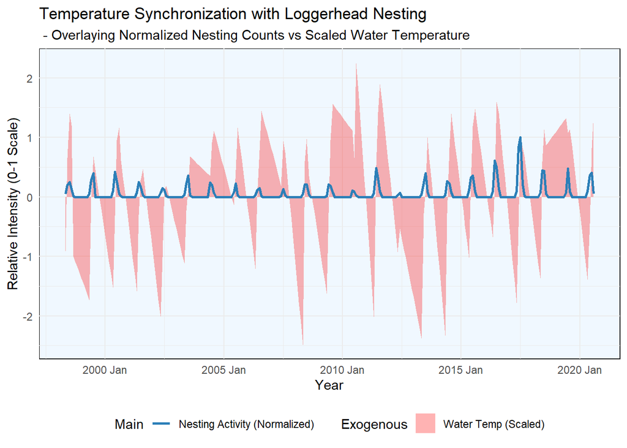

We used the KPSS $p$-value to evaluate Stationarity. The Null Hypothesis for the KPSS Test is that the data is stationary. The KPSS $p$-value was greater than 0.05, therefore we Fail to Reject the Null Hypothesis and we do not have enough evidence to conclude that the data is non-stationary. The actual KPSS Test Results were $p$ = 0.0868 for Nesting Activity, and $p$ = 0.1000 for Average Gulf Surface Temperature. However, the ADF Test yielded that the $p$-value was 0.01 for both nesting counts and temperature data, therefore, we Rejected the Null Hypothesis and the data was shown to be Stationary. While these results corroborated each other, subsequent visual inspections of the exploratory plots and statistically computed results show otherwise.

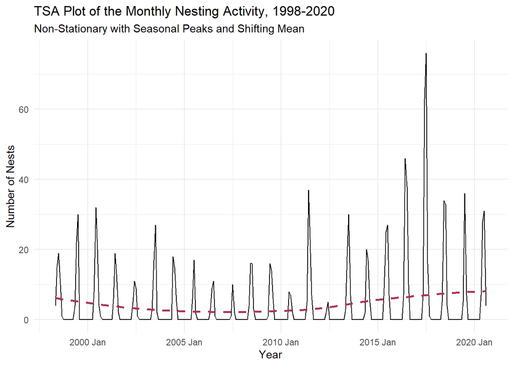

Figure 5: TSA Plot of Monthly Nesting Activity, 1998-2020

A Time Series Plot was configured (Figure 5) which revealed that the Mean and Variance were NOT constant due to the prominent peaks and valleys indicating a strong Seasonal influence. This is evidence that the data is, in fact, Non-Stationary because the plot clearly shows that the line is not straight which describes that the mean is shifting with time.

The STL decomposition function, from the feasts, O’Hara-Wild, Hyndman, and Wang (2025), package in R, was used to construct two component plots to identify if the data was best to undergo additive (Figure 6) or multiplicative decomposition (Figure 7).

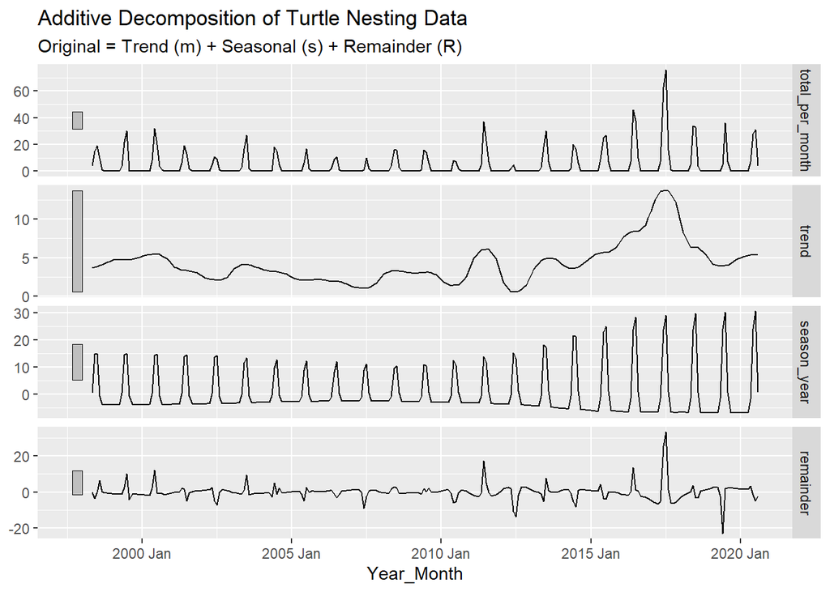

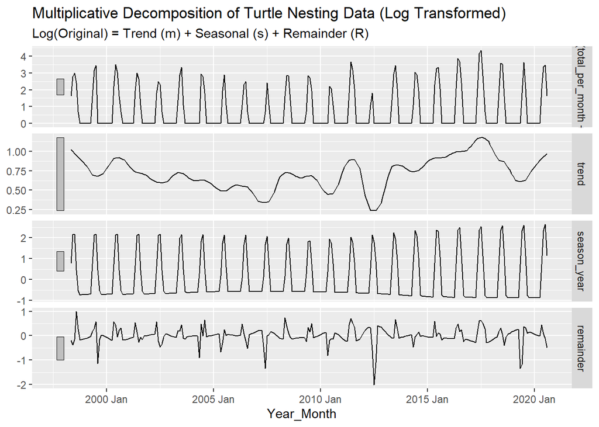

Figure 7: Multiplicative Decomposition of Turtle Nesting Data (Log Transformed)

The Nesting Trend Strength is 0.3163 (0.6 minimum) and considered weak in the SARIMAX model. Unfortunately, this does not bode well for nesting turtles since this shows that there is not a consistent upward trend, although spikes over the years are observed and more are possible in the future. The Strong Nesting Seasonal Strength (0.7951) revealed that there is a highly predictable season and can be seen directly in Table 9.

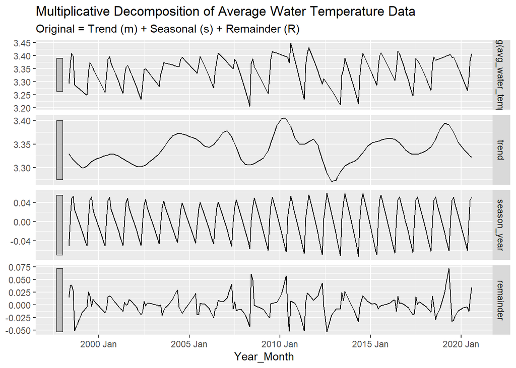

Figure 8: Multiplicative Decomposition of Average Water Temperature Data (Log Transformed)

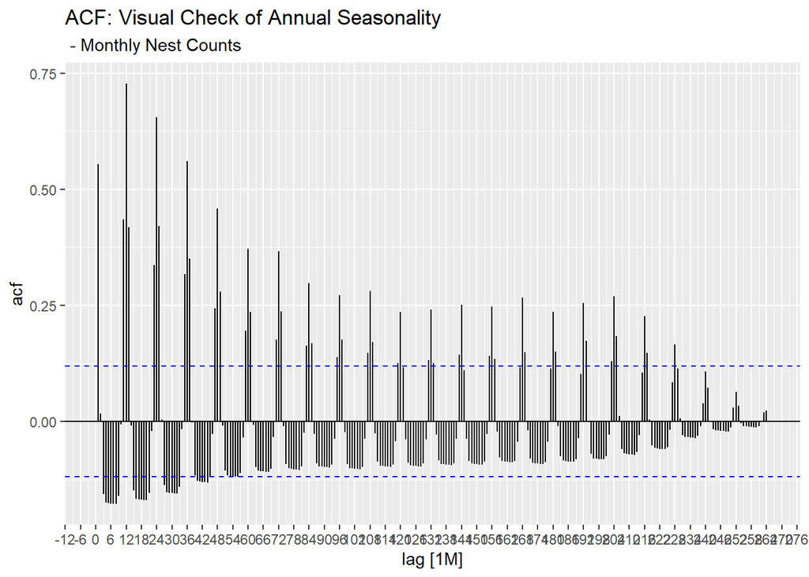

Figure 9: ACF: Visual Check of Annual Seasonality on Monthly Nest Counts

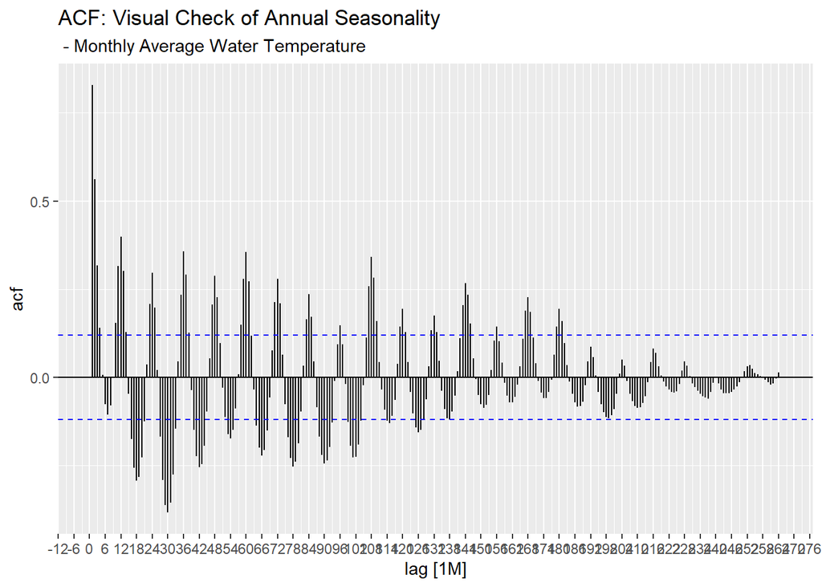

Figure 10: ACF: Visual Check of Annual Seasonality on Average Monthly Water Temperature

To begin our Model Selection process, we generated an ACF Plot (Figure 9) for nesting data and it revealed that there was Seasonality in the data showing yearly peaks. There was a definite trend since the bars stay high and decrease slowly over all lags. This also shows that, again, the mean was shifting over time and Differencing was confirmed to be required for SARIMAX modelling. The Water Temperature ACF Plot (Figure 10) shows that there was Seasonality in the data showing varied yearly peaks. There was a trend since the bars generally stay high and decrease slowly over all lags with minor fluctuations. This also corresponds to the mean shifting over time and supports Differencing.

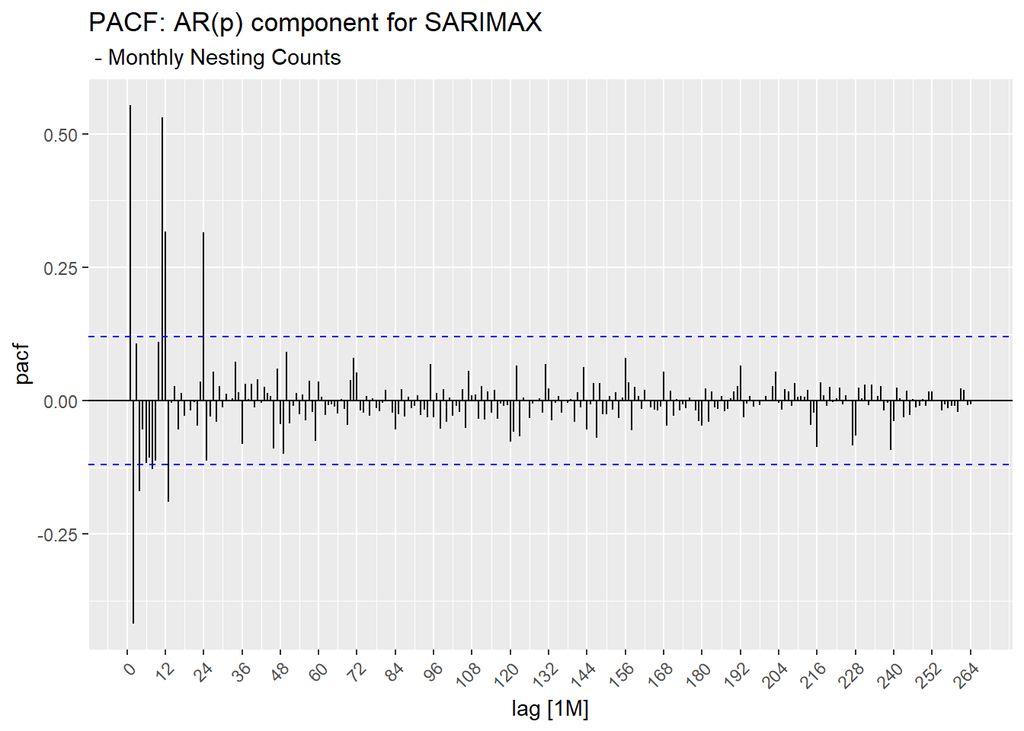

Figure 11: PACF: AR(p) component for SARIMAX on Monthly Nesting Counts

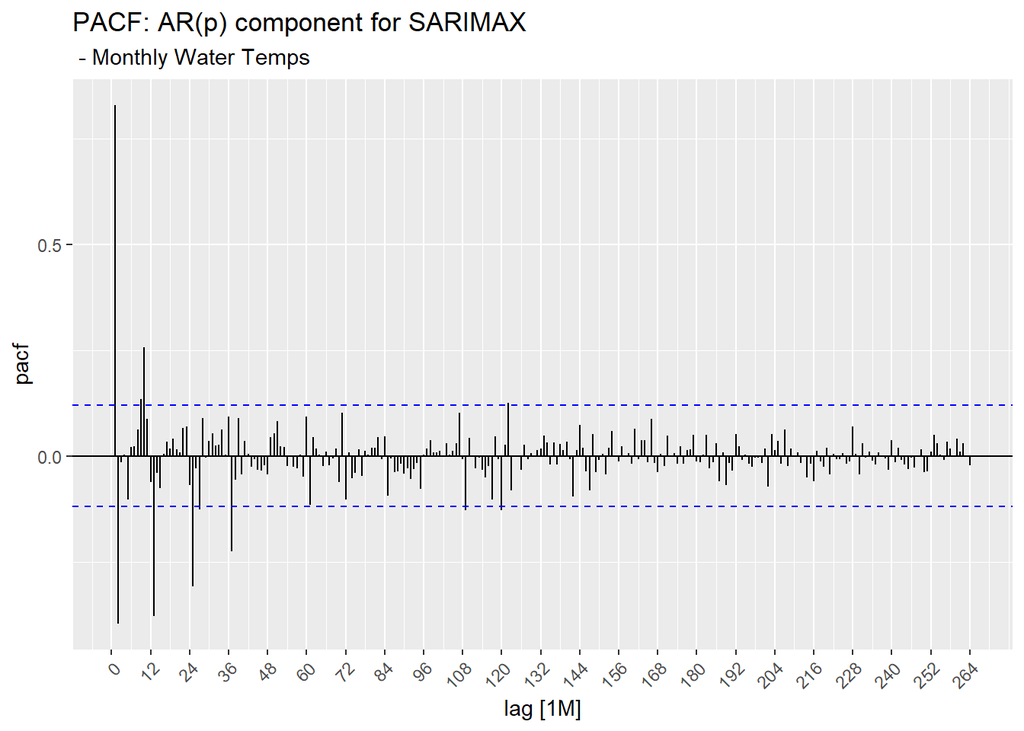

Figure 12: PACF: Visual Check of Annual Seasonality on Average Monthly Water Temperature

The PACF determines the order of AR via a “cutoff” point. The last significant cutoff point in the Nesting PACF plot (Figure 11) is at the 24 month mark after which the spikes are in, or very close to, the “insignificant zone” and is akin to “white noise”. This shows there is some direct correlation with the data’s own past values at the same time the previous year; therefore, $p$ = 0. The last significant cutoff point in the Temperature PACF plot (Figure 12) is at the 36 month mark after which the spikes are in the “insignificant zone” and is akin to “white noise”. This shows there is some direct correlation with the data’s own past values at the same time the previous year; therefore, $p$ = 0 still holds for the overall model behaviour.

Table 4: SARIMA Automatic Modelling Coefficients for Nesting Activity

SARIMA Automatic Modelling Coefficients

- ARIMA(0,0,2)(0,0,1)[12] for Nesting Activity

| Parameter | Coefficient | Std. Error | z-value |
| --- | --- | --- | --- |
| ma1 | 0.5897242 | 0.06214623 | 9.489300 |
| ma2 | 0.1361147 | 0.06143296 | 2.215662 |
| sma1 | -0.6914920 | 0.05525104 | -12.515457 |

The automatically-fitted model gives us ARIMA(0,0,2)(0,0,1)[12] and the backshift equation (6) is as follows:

$$\begin{equation}
y_t=(1+\theta_1 B+ \theta_2 B^2)(1+\Theta_1 B^{12})\epsilon_t
\end{equation}$$

The Time Series Plot showed that the mean and the variance were not constant and the mean was shifting and so the model is in need of Differencing. We must keep the model as parsimonious as possible but the model is invalid in its current form. Adding Differencing, D = 1, will satisfy the requirement to stabilize the data and, also, flatten out the mean over time. This model will be tested as a “neighbor” model during training and validation stage to verify its fit. Adding the Differencing adds a term to the left side of the model equation and mathematically interprets the annual changes in turtle nesting as shown below:

$$\begin{equation}
(1-B^{12})y_t=(1+\theta_1 B+ \theta_2 B^2)(1+\Theta_1 B^{12})\epsilon_t
=(1+0.6B+ 0.14B^2)(1-0.7B^{12})\epsilon_t
\end{equation}$$

In summary, the ARMA, or Autoregression (AR) and Moving Average (MA), base accounts for zero AR terms and a two month MA. The AR is zero because of the strong seasonality of the model ($P$ and $Q$ have more influence). Also, the exogenous surface water temperature shows that it holds the momentum of the monthly nesting activity and provides an innate seasonality to the model. The $S$ in SARIMA includes Seasonality to the ARIMA model; $P$, $D$, and $Q$ define the Seasonality of the model but only Seasonal Differencing, $D$, was needed to stabilize the mean. The $X$ in SARIMAX adds the exogenous (external) variable of Surface Water Temperature and also adds an environmental influence.The final “Neighboring” SARIMAX equation with respect to Nesting Activity, and included Differencing, is as follows:

$$\begin{equation}
SARIMAX(p,d,q)(P,D,Q)_{AnnualLag} = SARIMAX(0,0,2)(0,1,1)_{12}
\end{equation}$$

The Difference of $d$ = 0 is explained by the fact that our model needed long-term seasonal differencing, D; adding d=1 to the model would add another parameter and could make our model less efficient. Also, too much diferencing can lead to over-differencing which almost always leads to overfitting. There was a Seasonal Difference of $D$ = 1 specified for the model due to strong Seasonal Strength of both the nesting activity and the water temperature; it could also be that the dip in 2019 nesting activity could have been the slight disruption that set $D$ = 0 in the automatically generated model. There will be a Differencing Loss in the model; the use of the Seasonal Differencing ($D$=1) makes the model disregard the first 12 months of data since it has no previous time to compare with. The Autoaggressive component was $p$ = 0 since the number of nests found in one month does not have a ripple effect from the previous month possibly because turtles nest up to every two weeks (on average) during a season but only make an average of 4 nests over a maximum season of 5 months. The Seasonal Autoaggressive was $P$ = 0 because the number of nests found in one season does not have a ripple effect from the previous season possibly because turtles nest every two or more years (on average). Our Moving Average was $q$ = 2, the model has memory from the previous 2 months to adjust for the current month. The Seasonal Moving Average was $Q$ = 1 whereby the model is able to adjust for inconsistencies in nest counts from last year to the current year’s prediction. Inconsistencies can arise from weather deviations like cold snaps or hurricanes and other environmental disasters like the Gulf oil spill of Summer, 2010.

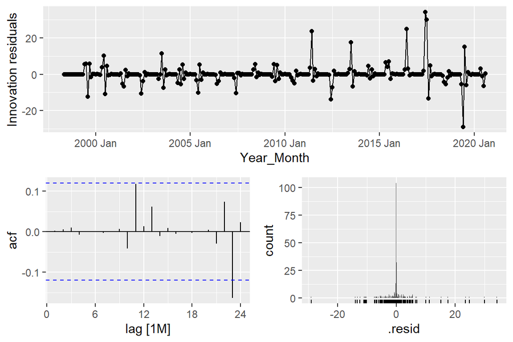

Figure 13: Nesting Residuals: Auto-generated SARIMA

The graphical representation of the residuals is shown in Figure 13. The following analysis proves that the Auto-generated ARIMA could be considered an accurate representation of the model. The Innovation Residuals show that the minor “shock” fluctuations mostly remain around a zero-mean like ideal “White Noise”. The unexpected negative influence (significant innovation or “shock”) at the end of the system shows that the model was not expecting the lower nesting numbers. Equation (9) explains how the “shocks” that occur in the system are represented to account for unpredictable fluctuations after seasonal and trend instances have been accounted for.

$$\begin{equation}
\epsilon_t = y_t - E[y_t|PastInformation]
\end{equation}$$

**TRAINING AND VALIDATION**

The Fourier Dynamic Regression Model ($k$=5) did well based on obtaining the lowest $\sigma^2$. However, we are evaluating the result with AIC scores; this would not be the most parsimonious mode given that $k$=5 and so there would be 5 sine/cosine pairs that would constitute 10 parameters plus the 3 parameters needed for the actual model. With too many parameters there is a risk of over-fitting and may not perform as well on unseen data. The data for 2019-2020 is set aside to be used to evaluate the model’s performance on new unseen data. The negatively-influenced nesting seasons of 2020 will test the robustness of the model’s ability to forecast effectively and accurately.

Per the R-Studio-generated warning, “automatic selection does not select models with characteristic roots that may be numerically unstable”(Hyndman 2025). The base_arima with Box-Cox (lambda = 0, log transform), Fourier 1, GAMs, and Prophet could not predict a model because a small change in data could make the model unstable. R-Studio ignores the unstable models and will choose something more reliable that will work in the long-term.

Table 5: AICc Scores (Ranked Lowest to Highest) of all Models

Models AICc Scores (Ranked Lowest to Highest)

- Partial Dataset, 1998-2019

| Model | AIC | AICc | BIC | Log Likelihood | Sigma Squ. |
| --- | --- | --- | --- | --- | --- |
| n_sarimax_002_011 | 1438.57 | 1438.74 | 1452.43 | -715.29 | 24.79 |
| temp_sarimax_002_011 | 1439.76 | 1440.03 | 1457.08 | -714.88 | 24.80 |
| auto_sarimax | 1440.81 | 1441.30 | 1465.06 | -713.41 | 24.73 |
| temp_sarimax | 1442.23 | 1442.87 | 1469.94 | -713.12 | 24.77 |
| fourier_sarimax_5 | 1502.59 | 1504.94 | 1558.80 | -735.29 | 23.22 |
| fourier_sarimax_6 | 1504.59 | 1507.25 | 1564.32 | -735.29 | 23.32 |
| fourier_sarimax_4 | 1505.83 | 1507.63 | 1555.02 | -738.92 | 23.67 |
| fourier_sarimax_3 | 1520.33 | 1521.66 | 1562.49 | -748.17 | 25.20 |
| fourier_sarimax_2 | 1540.69 | 1541.62 | 1575.82 | -760.34 | 27.44 |
| temp_sarimax_002_001 | 1625.62 | 1625.97 | 1646.70 | -806.81 | 39.56 |
| sarimax_002_001 | 1631.73 | 1631.97 | 1649.29 | -810.86 | 40.67 |
| gam_fourier_4 | 1636.54 | 1637.47 | 1671.67 | -808.27 | 41.16 |
| ets_model | 2260.67 | 2262.74 | 2313.38 | -1115.34 | 34.44 |
| base_snaive | NA | NA | NA | NA | 48.75 |

**FORECASTING**

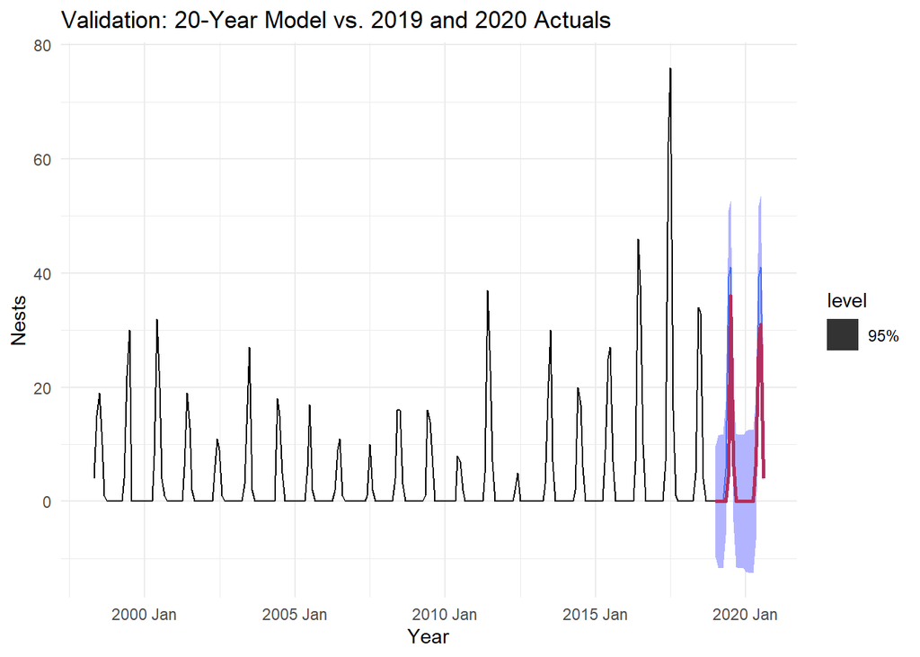

Figure 14: Validation Test Plot: 20-yr Model vs 2-yr Test Set

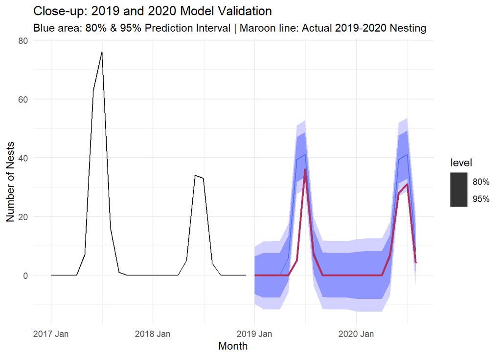

Figure 15: Validation Test Plot: 20-yr Neighbor Model with 2-yr Test Set

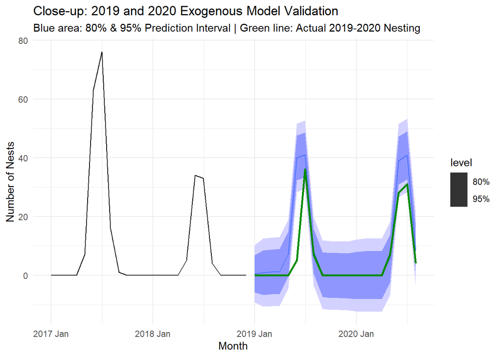

Figure 16: Validation Test Plot: 20-yr Exogenous Model with 2-yr Test Set

**METRICS**

To show that the selected SARIMAX frameworks are proven robust and efficient, one must disseminate the full range of statistical metrics using the Ljung-Box Test and a reassessment of the Composite Residual plots. The AIC (Akaike Information Criterion) score was the main driver for choosing the best model, our version of that was the most parsimonious.

Table 6: Ljung-Box Residual Test Results for Neighbor Model

Ljung-Box Residual Test Results

- n_sarimax_002_011

| Model | Q-Statistic | p-value |
| --- | --- | --- |
| n_sarimax_002_011 | 9.915858 | 0.9799837 |

Table 7: Ljung-Box Residual Test Results for Exogenous Model

Ljung-Box Residual Test Results

- temp_sarimax_002_011

| Model | Q-Statistic | p-value |
| --- | --- | --- |
| temp_sarimax_002_011 | 9.936386 | 0.979726 |

The variance of the residuals, $\sigma^2$ in Table 5, for the Neighbor SARIMAX had a $\sigma^2$ reaching a low of 24.79. The remaining noise is very minimal and the fit is pretty tight. The SNaive model gives a baseline $\sigma^2$ (48.75) for maximum seasonal volatility and our chosen model has been able to eliminate about half of the noise, essentially, extracting the patterns for the model to utilize.

The coefficients estimated in Table 4, have associated standard error and z-statistic terms define their significance. The relationship between the z-statistic, coefficient and standard error is shown in Equation (10). The “ma1”, or the first-order Moving Average, coefficient was 0.5897 and relates the fact that 59% of the “shock” (error) from the previous month is carried over the current month’s prediction. The “ma2”, or the second-order Moving Average, coefficient was 0.1361 and 14% of the “shock” (error) was carried over from 2 months previous to the current month’s prediction; this takes care of any 2-month ripple effects.

$$\begin{equation}
z = \frac{Coefficient}{StandardError}
\end{equation}$$

The “sma” coefficient represents the Seasonal Moving Average and is negative. This describes the ability for the model to subtract a portion of previous year’s error from the current time’s prediction, in essence, a dampener on past seasonal “shocks”. This helps the model remain stable through outlier seasons by not over-forecasting. The “s.e.”, or Standard Error, measures the reliability of ALL of the coefficients generated. If |z|>1.96, the coefficients have surpassed the threshold that proves they are significant. In conclusion, all of the coefficients are significant with “sma” being the most influential. This makes the 12-month “memory” the mechanism that powers through the annual fluctuations.

The Ljung-Box Test evidenced that the $p$-value was 0.9797 and is far greater than the 0.05 threshold required to prove that the model is statistically significant; therefore we Fail to Reject the Null Hypothesis. The residuals are proven to be White Noise and all significant patterns were absorbed by the model.

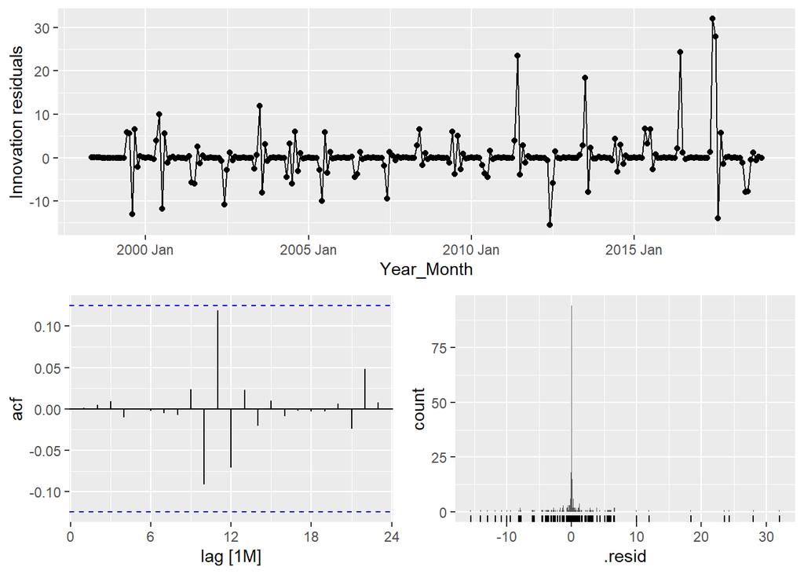

Figure 17: Final Residual Analysis: Neighbor Model

The Residual Composite plot of the Neighbor Model shows that the residuals are centered about zero which confirms that the errors are normally distributed. There is a minimal bias but this is evidenced as the model having a balanced fit. The ACF plot shows that all spikes are captured within the blue White Noise boundary lines. The Innovation Residual plot shows the the line crossing through zero consistently indicates that the mean is stable and that long-term trends have been tracked. The main difference in the Exogenous model Residual Composite Plot is that there is a higher concentration of errors about zero; the density of the errors confirms this model can extract more non-distinct patterns keeping the model statistically neutral.

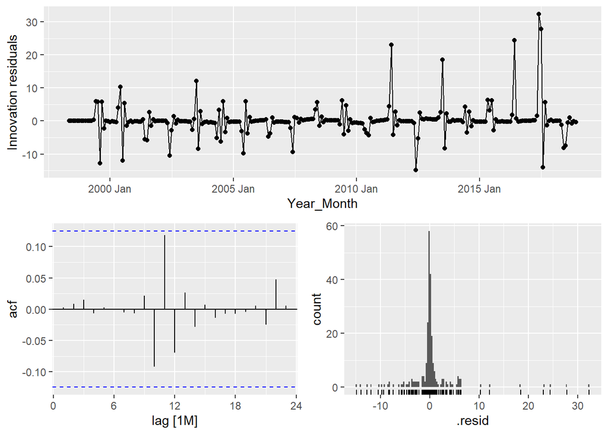

Figure 18: Final Residual Analysis: Exogenous Model

The Root Mean Squared Error (RSME) of the Neighbor model was 8.6348 meaning that our nest counts could be off by 9 per month; however, the Mean Average Error (MAE) was 3.6686 which means we could be off by 4 nests per month. When the system experiences a “shock”, the RSME will square this error, making it more noticable, whereas the MAE represents a typical month’s nesting and “ignores” the shock.

Root Mean Squared Error & Mean Average Error

- n_sarimax_002_011

| Model | RMSE | MAE |
| --- | --- | --- |
| n_sarimax_002_011 | 8.63478 | 3.668644 |

RSME and MAE for Neighbor Model

Root Mean Squared Error & Mean Average Error

- temp_sarimax_002_011

| Model | RMSE | MAE |
| --- | --- | --- |
| temp_sarimax_002_011 | 8.775639 | 3.959554 |

RSME and MAE for Exogenous Model

In conclusion, the average number of nests that the model prediction varies is approximately 4-9. This is the count that local conservationists can use to monitor the health of the local Loggerhead population during nesting season.

### DISCUSSION

Driven by our results, the nesting habits appear to be be predictable based on past nesting data and the exogenous variable, Average Water Temperature, which applied an additional layer of biological context needed for forecasting. We were able to track how similar the main and exogenous data was during exploratory phase. After generating a base model, we were able to distinguish that we had to make adjustments after analyzing plots (ACF and PACF) and conducting tests (ADF and KPSS). The seasonal strength was so pronounced ($F_S$ = 0.7951) that we had to add Differencing ($D$=1) to stabilize the shifting mean. We utilized the form of “Neigboring”, a strategy of testing like models with minimal parameter additions to preserve its parsimony. We then created the new Neighbor Model changing the original from ARIMA(0,0,2)(0,0,1)[12] to a SARIMA(0,0,2)(0,1,1)[12] to show the addition of Seasonal Differencing. All three models (base, Neighbor, and Exogenous) were included in our testing and validation strategy along with other models were good at handling non-linear data, e.g., Dynamic Harmonic Regression (Fourier), prophet, ETS, GAMs etc. We created an Exogenous Model using the Neighbor model as its base and it tested with the other models. The Neighbor Model had the best AIC score with the fewest parameters but the Exogenous Model was the second best performer with a difference of 1.19. The Neighbor and Exogenous models continued to be compared right till the end with final residual testing. We observed that the Exogenous Model had a more favorable residuals plot with a denser, more homoscedastic collection of residuals around the mean. This suggests that the Exogenous model provides a more sophisticated fit to handle the environmental “shocks” that are contained within the nesting data; however, using this as our final model would promote a biologically-driven causality hypothesis, for example, a rise in temperature would cause more nests to be laid which may not always be true. In contrast, the Neighbor model disseminates a statistically correlative hypothesis that relies on past nesting counts to predict new ones. Since this model has been proven to be the most parsimonious with high predictive accuracy (AIC score), this model is still our most powerful forecasting tool.

### LIMITATIONS

While we have discovered an extremely efficient surveillance tool, we can not ignore that external influences can reoccur and generate huge shocks that are difficult to mitigate like the Deep Horizon Oil Spill in 2010. The shocks will manifest in the residuals but it will always be obviously impossible to predict for future nesting counts. It would be interesting to monitor the models accuracy during a similar event (although never another oil spill as disastrous as Deep Horizon). Also, 2012 was another year that had several circumstances occurring at the same time; it had the cooler summer temperatures and it was two years after Horizon which may or may not have effected the Remigration of the turtles. Just as when hurricanes come into the area there is more anthropogenic activity in the area that can deter the turtles from coming ashore.

There is a spatial limitation on the temperatures recorded at the buoy so far from the coast (115 KM). The temperatures recorded at Station 42039 could be the “thermal” string that pulls the turtles into the region but not necessarily what makes them want to head for the beaches to nest; the temperature at the shoreline is likely very different compared to sea surface temperature. The shoreline temperature varies because of the tidal mix of the shallows, or sand bars, with deeper surrounding waters. This is why the Neighbor Model is preferable because past nest counts have been “privy” to these variations long before and have become inherent yet still is able forecast well.

### CONCLUSION

Our analysis can conclude that the nesting activity along the Gulf Coast is highly predictable, even after going through extraneous circumstances like hurricanes or oils spills. We were able to utilize the Box-Jenkins Method stages intertwined with the process of Time Series Analysis to apply rigor in our model development.

We can not ignore that the Exogenous model had better density of residuals, however, we can not be too reliant on that fact alone. Turtles are ectothermic, and surface water temperature surely guides them and their behavior, but the Station temperature used in our study may not have reflected the near-coastal temperatures accurately enough and only acted as a “thermal string” to coax the turtles closer to shore.

### FUTURE WORK

Table 9 shows the seasonal data taht could be used in a study to try to observe the peak nesting season in relation to the shifting of the length of the nesting season. Also, another study could look into the spatial clustering of the turtles and when they arrive at the beach to nest.

### ADDITIONAL TABLES AND VISUALIZATIONS

Table 8: Nesting Data with Scaled Temperature Table (Partial)

Nesting Data with Scaled Temperature

Partial

| Year | Total Nests | Avg Water Temp. | Scaled Temp. |
| --- | --- | --- | --- |
| 1998 May | 4 | 26.92500 | -0.9128759 |
| 1998 Jun | 15 | 29.17333 | 0.6594485 |
| 1998 Jul | 19 | 30.23684 | 1.4031908 |
| 1998 Aug | 10 | 29.95000 | 1.2025939 |
| 1998 Sep | 1 | 26.80000 | -1.0002920 |

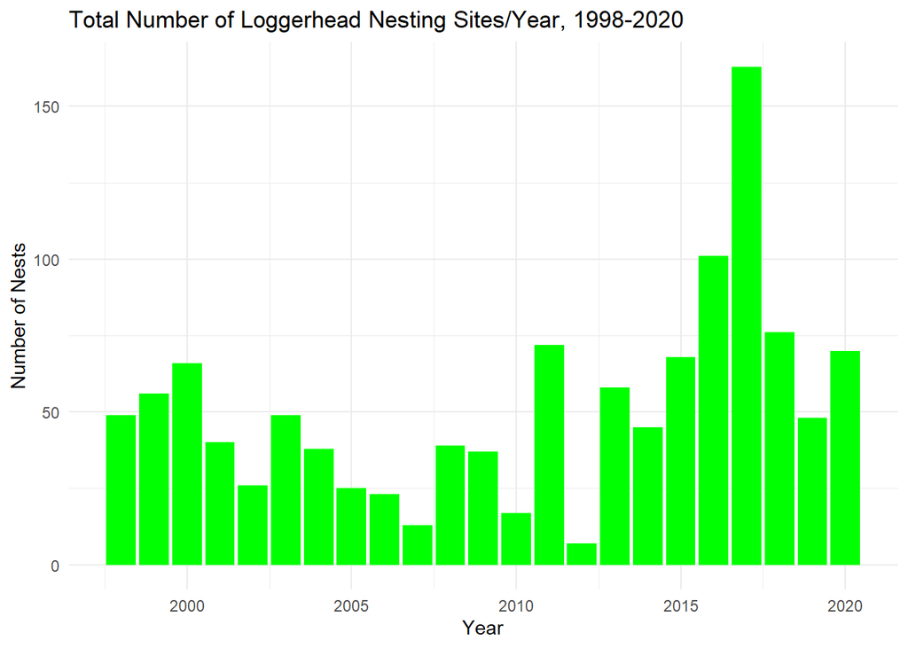

Figure 19: Total Number of Loggerheads Nesting Sites/Year, 1998-2020

Beach Area Nest Totals

| Location | Nest Total |
| --- | --- |
| Perdido Key | 366 |
| Santa Rosa Beach | 299 |
| Pensacola Beach | 278 |
| Fort Pickens | 243 |

Figure 20: Area Totals of Loggerhead Turtle Nesting Sites: 1998-2020

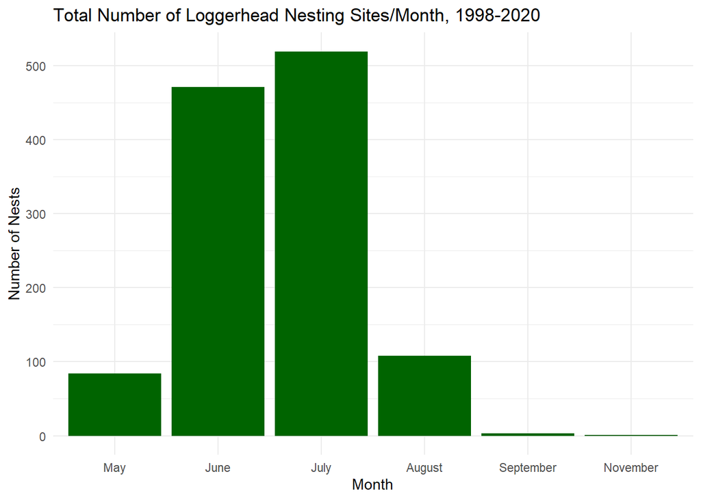

Figure 21: Total Number of Loggerhead Nesting Sites/Month, 1998-2020

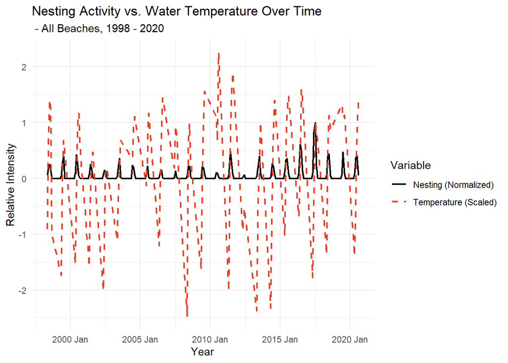

Annual Loggerhead Nesting Season Dates

- 1998-2020, Gulf Coast Study Area

| Year | Start Date | End Date | Total Sites |
| --- | --- | --- | --- |
| 1998 | 1998-05-23 | 1998-09-06 | 49 |
| 1999 | 1999-05-24 | 1999-07-20 | 56 |
| 2000 | 2000-05-09 | 2000-09-22 | 65 |
| 2001 | 2001-05-27 | 2001-08-12 | 40 |
| 2002 | 2002-05-03 | 2002-08-12 | 26 |
| 2003 | 2003-05-21 | 2003-08-04 | 49 |
| 2004 | 2004-06-08 | 2004-08-18 | 38 |
| 2005 | 2005-06-04 | 2005-08-11 | 25 |
| 2006 | 2006-05-25 | 2006-08-07 | 23 |
| 2007 | 2007-06-27 | 2007-08-06 | 13 |
| 2008 | 2008-05-21 | 2008-08-20 | 39 |
| 2009 | 2009-05-18 | 2009-08-21 | 37 |
| 2010 | 2010-06-07 | 2010-08-05 | 17 |
| 2011 | 2011-05-19 | 2011-08-21 | 72 |
| 2012 | 2012-05-23 | 2012-06-07 | 7 |
| 2013 | 2013-05-11 | 2013-08-14 | 58 |
| 2014 | 2014-05-20 | 2014-08-30 | 45 |
| 2015 | 2015-05-13 | 2015-08-31 | 68 |
| 2016 | 2016-05-18 | 2016-08-31 | 101 |
| 2017 | 2017-05-16 | 2017-09-05 | 163 |
| 2018 | 2018-05-19 | 2018-08-11 | 76 |
| 2019 | 2019-06-28 | 2019-08-30 | 48 |
| 2020 | 2020-05-22 | 2020-08-17 | 70 |

## References

Box, & Jenkins, G. E. P. 1970. *Time Series Analysis: Forecasting and Control*. San Francisco, CA: Holden-Day.

FWC. 2011. “Federal Register.” 2011. https://www.federalregister.gov/.

———. 2025. “Florida Fish and Wildlife Conservation Commission.” 2025. https://myfwc.com/.

Grolemund, Garrett, and Hadley Wickham. 2011. “Dates and Times Made Easy with lubridate.” *Journal of Statistical Software* 40 (3): 1–25. https://www.jstatsoft.org/v40/i03/.

Hyndman, Rob. 2025. *Fpp3: Data for "Forecasting: Principles and Practice" (3rd Edition)*. https://doi.org/10.32614/CRAN.package.fpp3.

Iannone, Richard, Joe Cheng, Barret Schloerke, Ellis Hughes, Alexandra Lauer, JooYoung Seo, Ken Brevoort, and Olivier Roy. 2025. *Gt: Easily Create Presentation-Ready Display Tables*. https://doi.org/10.32614/CRAN.package.gt.

Insights, Science. 2025. “Why Do Turtles Migrate? The Reasons Behind the Journey.” *Scienceinsights.org*.

Jacob Andrew Lasala, Kristen T. Mazzarella, Melissa C. Macksey. 2023. “Forty Years of Monitoring Increasing Seas Turtle Relative Abundance in the Gulf of Mexico.” 2023. https://www.nature.com/articles/s41598-023-43651-4.

MathWorks. 2026. “Time Series Analysis.” 2026. https://www.mathworks.com/discovery/time-series-analysis.html.

Mazaris, Matsinos, Kornaraki. 2004. “Modeling the Effect of Sea Surface Temperature on Sea Turtle Nesting Activities by Investigating Seasonal Trends.” *Natural Recourse Modeling*.

Miller, Musick, Lutz. 1997. *Reproduction in Sea Turtles*. *The Biology of Sea Turtles, Vol 1, Pp51-81*. Boca Raton, FL: CRC Press.

NOAA. 2025. “Deepwater Horizon.” 2025. https://darrp.noaa.gov/oil-spills/deepwater-horizon.

———. n.d. “National Data Buoy Center.” https://www.ndbc.noaa.gov/obs.shtml.

O’Hara-Wild, Mitchell. 2020. *Fable.prophet: Prophet Modelling Interface for ’Fable’*. https://doi.org/10.32614/CRAN.package.fable.prophet.

O’Hara-Wild, Mitchell, Rob Hyndman, and Earo Wang. 2025. *Feasts: Feature Extraction and Statistics for Time Series*. https://doi.org/10.32614/CRAN.package.feasts.

Pedersen, Thomas Lin. 2025. *Patchwork: The Composer of Plots*. https://doi.org/10.32614/CRAN.package.patchwork.

Robinson, David, Alex Hayes, and Simon Couch. 2025. *Broom: Convert Statistical Objects into Tidy Tibbles*. https://doi.org/10.32614/CRAN.package.broom.

Sato, Tanaka, Matsuzawa. 1998. “Internesting Intervals for Loggerhead Turtles, Caretta Caretta, and Green Turtles Chelonia Mydas, Are Affected by Temperature.” *Canad. J.Zool.76, 1651-1662*.

Sayali. 2025. “Beyond the Black Box: Understanding Prophet Through ’Forecasting at Scale’.” 2025. https://blog.stackademic.com/beyond-the-black-box-understanding-prophet-through-forecasting-at-scale-16d9a06759e3.

Trapletti, Adrian, and Kurt Hornik. 2026. *Tseries: Time Series Analysis and Computational Finance*. https://doi.org/10.32614/CRAN.package.tseries.

Wang, Earo, Dianne Cook, and Rob J Hyndman. 2020. “A New Tidy Data Structure to Support Exploration and Modeling of Temporal Data.” *Journal of Computational and Graphical Statistics* 29 (3): 466–78. https://doi.org/10.1080/10618600.2019.1695624.

Weigt, George. 2025. *Itsmr: Time Series Analysis Using the Innovations Algorithm*. https://doi.org/10.32614/CRAN.package.itsmr.

Wickham, Hadley. 2016. *Ggplot2: Elegant Graphics for Data Analysis*. Springer-Verlag New York. https://ggplot2.tidyverse.org.

Wickham, Hadley, and Jennifer Bryan. 2025. *Readxl: Read Excel Files*. https://doi.org/10.32614/CRAN.package.readxl.

Wickham, Hadley, Romain François, Lionel Henry, Kirill Müller, and Davis Vaughan. 2023. *Dplyr: A Grammar of Data Manipulation*. https://doi.org/10.32614/CRAN.package.dplyr.

Wickham, Hadley, and Lionel Henry. 2025. *Purrr: Functional Programming Tools*. https://doi.org/10.32614/CRAN.package.purrr.

Xie, Yihui. 2025. *Knitr: A General-Purpose Package for Dynamic Report Generation in R*. https://yihui.org/knitr/.

Zhu, Hao. 2024. *kableExtra: Construct Complex Table with ’Kable’ and Pipe Syntax*. https://doi.org/10.32614/CRAN.package.kableExtra.